# Datathon: Hands-on Afternoon Activity

Author

UCSB Data Day – Southern California Consortium for Data Science

Published

March 7, 2026

## Channel Islands

The **Channel Islands** are a chain of eight islands located off the southern coast of California in the Pacific Ocean. They are known for their stunning natural beauty, ecological richness, and deep cultural history.

#### The Eight Channel Islands (North to South)

1. **San Miguel Island**
2. **Santa Rosa Island**
3. Santa Cruz Island
4. Anacapa Island
5. Santa Barbara Island
6. San Nicolas Island
7. San Clemente Island
8. Santa Catalina Island

Below we will only consider the two bolded islands: SMI and SRI

#### [Channel Islands National Park](https://www.nps.gov/chis/index.htm)

- Includes **five islands**: *San Miguel*, *Santa Rosa*, *Santa Cruz*, *Anacapa*, and *Santa Barbara*.
- Sometimes called the “Galápagos of North America” for its rich biodiversity and many **endemic species**.
- Accessible only by *boat or small plane*.
- Ideal for hiking, kayaking, camping, and wildlife observation.

**Cultural and Historical Significance**:

- Originally inhabited by [**Chumash** and **Tongva**](https://www.nps.gov/chis/learn/historyculture/nativeinhabitants.htm#:~:text=With%20a%20current%20population%20nearly,organized%20Chumash%20tribal%20groups%20exist) indigenious groups for thousands of years.
- Home to important archaeological and cultural heritage sites.

## Island Fox (*Urocyon littoralis*)

The **island fox** is a small, charismatic canid species *endemic* to six of the eight *Channel Islands* off the coast of southern California. It’s one of the best examples of **island dwarfism**, having evolved from the mainland gray fox (*Urocyon cinereoargenteus*) to become significantly smaller.

In the **1990s**, several island fox populations faced **near extinction** due to golden eagle predation, canine distemper virus, and habitat degradation. The island fox was listed as endangered in 2004. Recovery efforts of the island fox included removal of golden eagles, vaccination and captive breeding programs, reintroduction of native bald eagles, and habitat restoration.

## Mini Datathon

First, please go through the Introduction which includes data preparation and some basics of how this dataset looks like. Then start with Part I which has a collection of analysis questions for you to work through. Depending on your level of comfort, take also a look at Part II which has some more Advanced challenges. If you’re ambitious, you can do both, or even come up with your own questions. There are definitely more challenges listed than what is feasible to do in 90 minutes, so tackle those that are of most interest to you. Remember that data science is always about combining numbers/tables and figures into a *story*. Coding and statistics are just tools to get there. So for instance, if you’re fascinated about how/why foxes are being vaccinated, it’s totally ok to google for additional background.

We have an **Optional Share-Out** during the last portion of the Datathon: participants can present one result of their choosing to the group. If you would like to do so, make sure to invest time in making a nice plot: play around with the plot `theme`, font sizes, color palettes, labels and layout. Google (via its automatic Gemini search results) is a good tool to dive deep into the myriad ggplot customization options. Note that *everything* in the plot can be customized to your choosing, which is (one of) the power of using a statistical package.

**If you are stuck at any point of the Datathon, raise your hand and a Data Guide will help you out**

## Data and Prep

The data provided is part of an ongoing longitudinal study of island foxes from 2014 to 2016 of trap monitoring. This resulted in collection of 4,975 recorded trap observations, which may have contained a fox or not. Other information collected were Sex, Age Class, Weight, Body Condition, Reproductive Status, and Vaccinations. Information on the data collected can be found in the [Databook](https://github.com/mludkov/UCSB_Data_Day_2026/blob/gh-pages/data_for_datathon_2014_2016.csv).

### Loading Packages

The `tidyverse` suite is a collection of data analysis packages:

```r
library(tidyverse)
library(knitr)
```

### Loading Data

Our dataset is in CSV (comma delimited text) file. You can open such files in a spreadsheet or with a text editor. For our purposes, you first need to download the file (or upload it to your cloud environment) and then load the data into the R workspace using the `read_csv` function:

```r
# Might need to modify next line to load the file from the location where you downloaded it
df <- read_csv(here::here("data_for_datathon_2014_2016.csv")) # Loads the Data Set into the object df
knitr::kable(head(df))
```

| Island | SamplingYear | GridCode | TrapDate | NightNumber | TrapNumber | TrapResult | Pittag | CaptureType | Sex | AgeClass | Weight | Weight_units | BodyCondition | ReproductiveStatus | Vaccinations |
| --- | --- | --- | --- | --- | --- | --- | --- | --- | --- | --- | --- | --- | --- | --- | --- |
| SMI | 2014 | CC | 2014-09-17 | 1 | 73 | OPEN | NA | NA | NA | NA | NA | NA | NA | NA | NA |
| SMI | 2014 | CC | 2014-09-17 | 1 | 74 | OPEN | NA | NA | NA | NA | NA | NA | NA | NA | NA |
| SMI | 2014 | CC | 2014-09-17 | 1 | 75 | OPEN | NA | NA | NA | NA | NA | NA | NA | NA | NA |
| SMI | 2014 | CC | 2014-09-17 | 1 | 76 | FOX | 485E224908 | P | Male | 4 | 2.36 | kg | 2 | TD | NA |
| SMI | 2014 | CC | 2014-09-17 | 1 | 77 | FOX | 484C1A2F21 | P | Male | 3 | 1.94 | kg | 2 | TD | NA |
| SMI | 2014 | CC | 2014-09-17 | 1 | 78 | FOX | 484C593840 | P | Female | 4 | 2.06 | kg | 2 | NA | NA |

### Cleaning Data

#### Renaming Categories

Looking at the [Codebook](https://github.com/mludkov/UCSB_Data_Day_2026/blob/gh-pages/IslandFoxes_codebook.pdf), the variables `Vaccinations`, `ReproductiveStatus` and `BodyCondition` are coded in interesting ways. In `Vaccinations`, missing values (`NA`) are considered as not vaccinated; therefore, changing the missing to “NV” will ensure that they are correctly classified. In `ReproductiveStatus`, the missing values (`NA`) indicate unknown reproductive status. In `BodyCondition`, the numerical values 1, 2, 3, 4, and 5, represent a condition. To make the condition easier, we will convert them to the categories. Run the code below to alter them:

```r
df <- df |> mutate( # Will change the variables in the df data set
    Vaccinations = case_when(is.na(Vaccinations) ~ "NV", .default = Vaccinations), # Reclassifies Missing Data in Vaccination as "N" per code book.
    ReproductiveStatus = case_when(is.na(ReproductiveStatus) ~ "UN", .default = ReproductiveStatus), # Reclassifies Missing Data in Vaccination as "N" per code book.
    BodyCondition = case_when( # Begins to modify BodyCondition
        as.character(BodyCondition) == "1" ~ "emaciated", # Changes 1 to emaciated
        as.character(BodyCondition) == "2" ~ "thin", # Changes 2 to thin
        as.character(BodyCondition) == "3" ~ "healthy wild", # Changes 3 to healthy wild
        as.character(BodyCondition) == "4" ~ "extra fat reserves", # Changes 4 to Extra Fat Reserve
        as.character(BodyCondition) == "5" ~ "extreme fat reserves" # Changes 5 to Extreme Fat Reserves
        )
    )
```

#### Missing Values

Several variables in the data set may be missing. Using the `summary()`, we can determine which variables have missing values by looking at the “NA’s” category.

```r
summary(df)
```

```
    Island           SamplingYear    GridCode
 Length:4975        Min.   :2014   Length:4975
 Class :character   1st Qu.:2014   Class :character
 Mode  :character   Median :2015   Mode  :character
                    Mean   :2015
                    3rd Qu.:2016
                    Max.   :2016

    TrapDate                    NightNumber      TrapNumber
 Min.   :2014-07-16 00:00:00   Min.   :1.000   Min.   :  1.00
 1st Qu.:2014-08-24 00:00:00   1st Qu.:2.000   1st Qu.:  4.00
 Median :2015-08-12 00:00:00   Median :3.000   Median :  8.00
 Mean   :2015-08-25 01:31:27   Mean   :3.392   Mean   : 18.87
 3rd Qu.:2016-08-18 00:00:00   3rd Qu.:5.000   3rd Qu.: 11.00
 Max.   :2016-11-30 00:00:00   Max.   :6.000   Max.   :108.00

  TrapResult           Pittag          CaptureType            Sex
 Length:4975        Length:4975        Length:4975        Length:4975
 Class :character   Class :character   Class :character   Class :character
 Mode  :character   Mode  :character   Mode  :character   Mode  :character




    AgeClass         Weight       Weight_units       BodyCondition
 Min.   :0.000   Min.   :  0.72   Length:4975        Length:4975
 1st Qu.:1.000   1st Qu.:  1.73   Class :character   Class :character
 Median :1.000   Median :  2.02   Mode  :character   Mode  :character
 Mean   :1.557   Mean   : 49.49
 3rd Qu.:3.000   3rd Qu.:  2.30
 Max.   :4.000   Max.   :910.00
 NA's   :2840    NA's   :2808
 ReproductiveStatus Vaccinations
 Length:4975        Length:4975
 Class :character   Class :character
 Mode  :character   Mode  :character
```

We notice that the variables `AgeClass`, `Weight`, and `BodyCondition` have missing values. **For this analysis, we will remove the missing values (`NA`).**

```r
df <- drop_na(df, AgeClass, Weight, BodyCondition) # Removes the missing values (NA) using the variables AgeClass, Weight, and BodyCondition
```

**After cleaning the data, this should result in 1,967 recorded foxes!** This is the dataset that we will be using for the rest of this activity.

```r
nrow(df)
```

```
[1] 1967
```

## Part I:

### Fox Weight Analysis

Imagine you’re a field biologist tracking animal health across the remote Santa Rosa and San Miguel Islands. You’ve noticed that some animals seem heavier in certain years—but is it just your imagination, or is there a real trend?

The `Weght` variable contains information of the Fox’s weight in kilograms. Let’s start by calculating the mean weight and standard deviation of weight using `mean()` and `sd()` functions:

```r
mean_weight<-mean(df$Weight)
sd_weight<-sd(df$Weight)
mean_weight
```

```
[1] 1.940275
```

```r
sd_weight #printing the values
```

```
[1] 0.4140872
```

We see that mean weight of a fox is about 1.9 kg (which is about 4 pounds) with standard deviation about .41 kg.

We use the `table()` and `prop.table()` functions to get the frequencies and proportions for the `Sex`.

```r
count_df <- table(df$Sex) # Using the 'Sex' variable from the `df` data set, we count the frequencies of each category with the table function and storing it in rs_df.
count_df # Printing out the contents of "rs_df"
```

```
Female   Male
   923   1044
```

Using the `table()` function, we can see that there were 923 female and 1044 male Foxes captured.

```r
prop.table(count_df) # Computing the Proportions of "rs_df"
```

```
   Female      Male
0.4692425 0.5307575
```

The `prop.table()` function shows the respective percentages: there are slightly more male Foxes (about 53%) vs. female Foxes (about 47%).

We can visualize the data using the `ggplot` functions. Namely we build a bar plot that shows those above counts visually (with more Male than Female foxes):

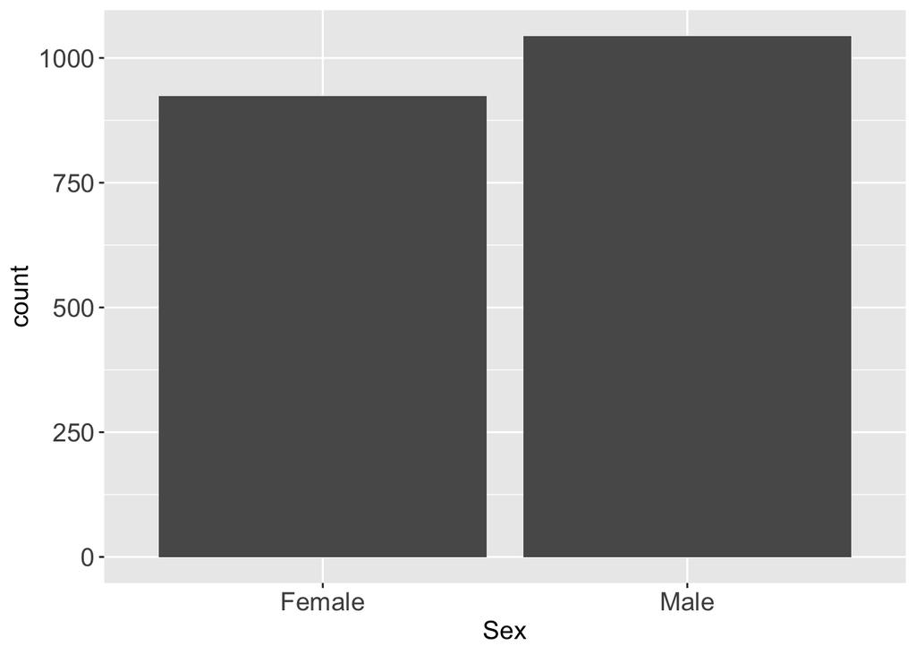

```r
ggplot(df) + # Setting up the data to create a plot.
  geom_bar(aes(Sex)) + # Creating a bar chart based on the variable "ReproductiveStatus"
  theme(axis.title = element_text(size = 14), axis.text = element_text(size = 14))
```

### Weight vs Sex

Let’s visualize the variable `Weight` and `Sex` with a boxplot using `ggplot`:

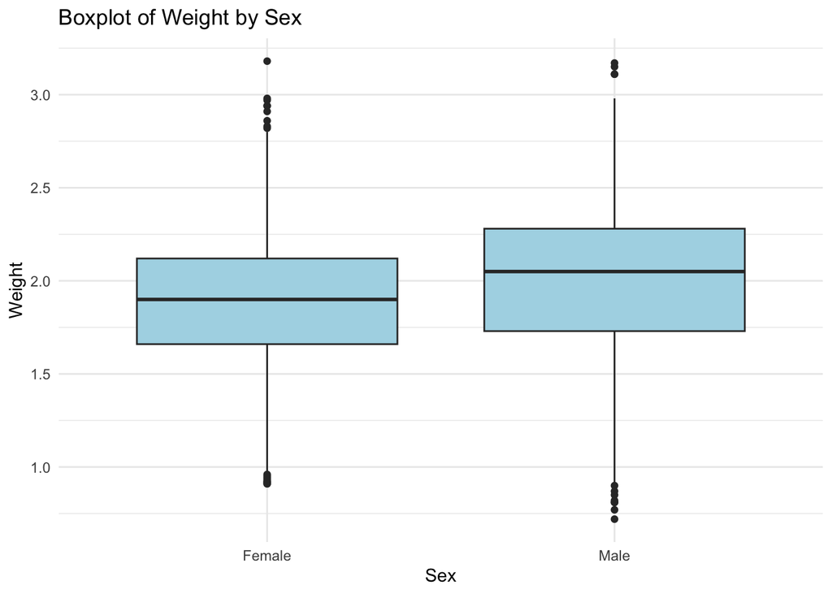

```r
ggplot(df, aes(x = Sex, y = Weight)) +
  geom_boxplot(fill = "lightblue") +
  labs(
    title = "Boxplot of Weight by Sex",
    x = "Sex",
    y = "Weight"
  ) + theme_minimal()
```

From the box plot we see that male Foxs tend to be slightly *heavier* than female Foxes.

We can use `group_by()` function to separate male from female population and calculate means and standard deviations separately:

```r
weight_summary <- df %>%
  group_by(Sex) %>%
  summarise(
    mean_weight = mean(Weight),
    sd_weight = sd(Weight),
    .groups = "drop"
  )
weight_summary
```

```
# A tibble: 2 × 3
  Sex    mean_weight sd_weight
  <chr>        <dbl>     <dbl>
1 Female        1.88     0.386
2 Male          1.99     0.431
```

This table confirms that male Foxes are slightly heavier, with mean weight of about 1.99 kg, than female Foxes, whose mean weight is about 1.88 kg. Standard deviations are also slightly higher for male Foxes.

#### Weight vs Sex over time

To see weight vs sex trend over time we can use `group_by()` and `ggplot` functions again:

```r
weight_summary_yearly <- df %>%
  group_by(Sex, SamplingYear) %>%
  summarise(
    mean_weight = mean(Weight, na.rm = TRUE),
    sd_weight = sd(Weight, na.rm = TRUE),
    .groups = "drop"
  ) #group the data by Sex and Year and calculate mean and standard deviation of weight
weight_summary_yearly
```

```
# A tibble: 6 × 4
  Sex    SamplingYear mean_weight sd_weight
  <chr>         <dbl>       <dbl>     <dbl>
1 Female         2014        1.95     0.362
2 Female         2015        1.85     0.409
3 Female         2016        1.86     0.373
4 Male           2014        2.08     0.405
5 Male           2015        1.95     0.451
6 Male           2016        1.99     0.419
```

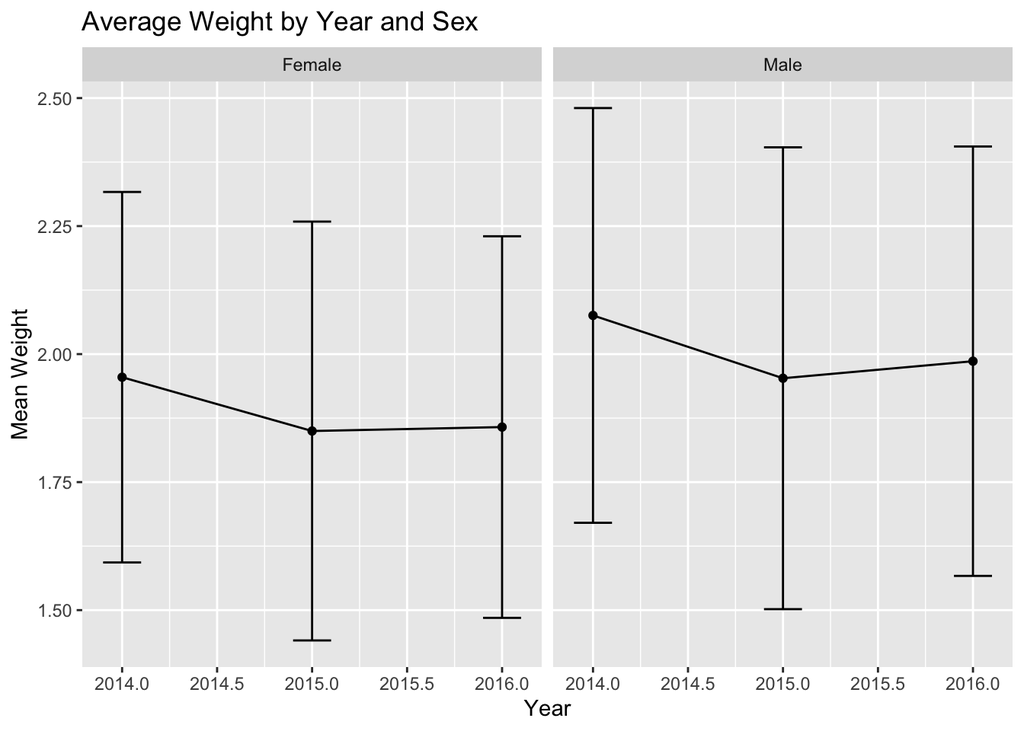

```r
ggplot(weight_summary_yearly, aes(x = SamplingYear, y = mean_weight)) +
  geom_line() +
  geom_point() +
  geom_errorbar(aes(ymin = mean_weight - sd_weight,
                    ymax = mean_weight + sd_weight), width = 0.2) +
  facet_wrap(~ Sex) +
  labs(
    title = "Average Weight by Year and Sex",
    y = "Mean Weight",
    x = "Year"
  )
```

**Weight vs Sex over time by Island**

Here is a first question for you to answer: do the foxes on different islands have the same weight? Is there an island where the foxes are **significantly** heavier than others? To conduct such analysis, you can filter by different `Islands`:

```r
#Santa Rosa Fox population

SR_df<-filter(df,Island=="SRI")

#San Miguel Fox population
SM_df<-filter(df,Island=="SMI")
```

### Questions to Try Out

**Vaccinations**

Do vaccinated foxes have a different weight compared to unvaccinated ones? To answer this, study the relationship between `Weight` and `Vaccinations`

**Body Condition**

The dataset has a variable called `BodyCondition`. What proportion of foxes are well nourished? Do some islands have a larger proportion of “fat” foxes than others? How does `BodyCondition` connect with `Weight`? For the latter, you could look into scatter plots.

### Fox Reproductive Status Analysis

The `ReproductiveStatus` variable contains information of the Fox’s reproductive status when captures. This data is recorded as “N” (Not actively reproductive), “L” (Lactating), “SL” (Signs of Lactating), and “TD” (Testes Distended).

We will use the `table()` and `prop.table()` function to get the frequencies and proportions for the `ReproductiveStatus`.

```r
rs_df <- table(df$ReproductiveStatus) # Using the 'ReproductiveStatus' variable from the `df` data set, we count the frequencies of each category with the table function and storing it in rs_df.
rs_df # Printing out the contents of "rs_df"
```

```
   L   SL   TD   UN
  18  244 1030  675
```

```r
prop.table(rs_df) # Computing the Proportions of "rs_df"
```

```
          L          SL          TD          UN
0.009150991 0.124046772 0.523640061 0.343162176
```

Using the `prop.table()` function, we can see that that the most common status is “TD” at 52.4% and the least common is “L” at the 0.9%. Both “SL” and “UN” represent 12.4% and 34.3% of the data, respectively. In barplot format we have:

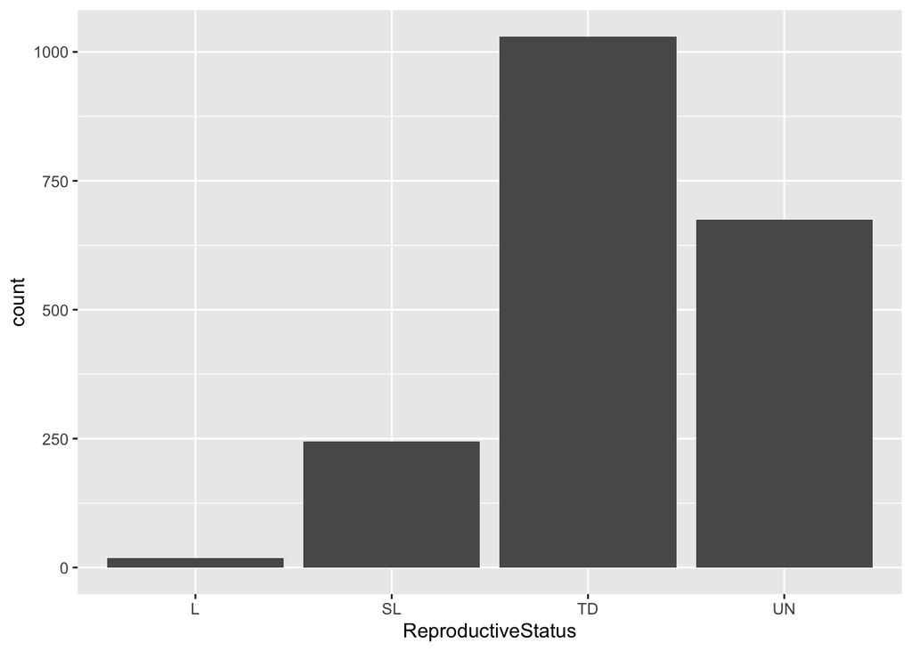

```r
ggplot(df) + # Setting up the data to create a plot.
  geom_bar(aes(ReproductiveStatus)) # Creating a bar chart based on the variable "ReproductiveStatus"
```

#### Sex and Reproductive Status

Let’s compare the frequencies between the variables `Sex` and `Reproductive Status`. We will be using the same `table()` function:

```r
xy_df <- table(df$ReproductiveStatus, df$Sex)
# Use the variables "ReproductiveStatus" and "Sex" from the "df" data set
# Use the table function to compute the crosstabs
# Store the results in the xy_df object

xy_df # Print results out
```

```
     Female Male
  L      18    0
  SL    244    0
  TD      0 1030
  UN    661   14
```

The results show that certain categorical combinations between `ReproductiveStatus` and `Sex` are 0, which is to be expected. The category “UN” is found in both Male and Female foxes. Looking at Female foxes, The most common type is “UN”, followed by “SL”. For Male foxes, the most common type was “TD”.

Let’s find the proportions for each the combination of the variables using the `prop.table()` function.

```r
prop.table(xy_df)
```

```
          Female        Male
  L  0.009150991 0.000000000
  SL 0.124046772 0.000000000
  TD 0.000000000 0.523640061
  UN 0.336044738 0.007117438
```

We can see that 52.4% of the data are Male and “TD” foxes, 33.6% of the data are Female and “UN” foxes, and 12.4% of the data are Female and “SL” foxes. To visualize how the variable `ReproductiveStatus` and `Sex` related to each other we use a stacked bar plot:

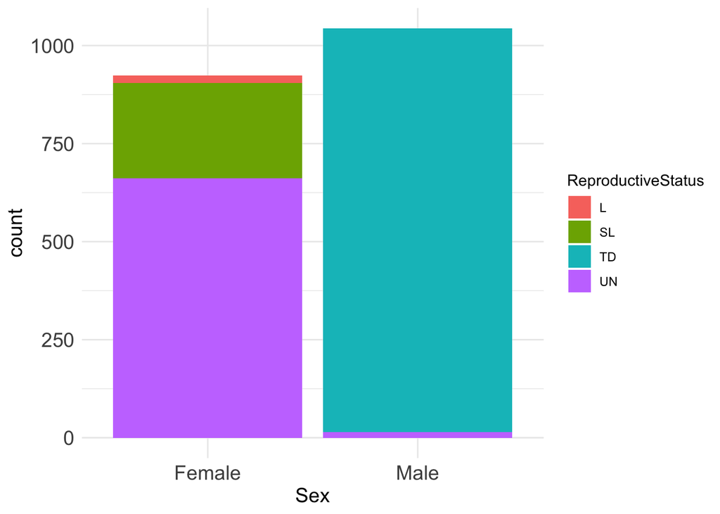

```r
ggplot(df) +
  geom_bar(aes(Sex, fill = ReproductiveStatus)) +
  theme_minimal() +
  theme(axis.title = element_text(size = 14), axis.text = element_text(size = 14))
```

The plot indicate which categories are most dominant in each sex. We can see that the most dominant reproductive status in Male foxes is testes distended. For Female foxes, we can see that the most common reproductive status is Unknown.

### Challenges

The list below is quite long: pick and choose the challenges that appeal to you the most.

**Age Class**

How does `ReproductiveStatus` relate to `AgeClass` (how old is the fox), to `Vaccinations`, and to `Capture Type`?

**Skunking**

Reload the full dataset of 4975 record (not just foxes, and with all the NAs). How many skunks were caught each year? Are there more skunks on some island than others? (Look at `TrapResult`. Note that some skunks were caught but escaped, see the different possible values of this field!)

**Fox Ages**

What is the Age distribution of the foxes? How many foxes are less than 1 year old? Does this vary by year or by island? (Look at `AgeClass`. Notice that it’s a numeric variable)

**Trap Effectiveness**

(This is again about the full dataset with 4975 records). Analyze how often do the traps work (expressed as a success percentage). Namely, which Island and which Years yield the most foxes?

**Record Foxes**

A fun exercise is to analyze the extreme fox records. What was the fattest fox ever caught (break this out by Year, by Sex, and by Island)? What is the latest date of a fox capture in this dataset? What is the oldest fox?

## Part 2: Additional Challenges For More Advanced Participants

### Tracking Foxes

Each fox gets a unique Pit Tag. This `Pittag` field allows to track a specific fox across time. For example, let’s consider fox with tag 989001000124022. It shows up in the following records:

```r
knitr::kable(df[which(df$Pittag==989001000124022),])
```

| Island | SamplingYear | GridCode | TrapDate | NightNumber | TrapNumber | TrapResult | Pittag | CaptureType | Sex | AgeClass | Weight | Weight_units | BodyCondition | ReproductiveStatus | Vaccinations |
| --- | --- | --- | --- | --- | --- | --- | --- | --- | --- | --- | --- | --- | --- | --- | --- |
| SRI | 2016 | QC | 2016-08-03 | 1 | 1 | FOX | 989001000124022 | N | Female | 1 | 2.55 | kg | healthy wild | UN | RD |
| SRI | 2016 | QC | 2016-08-05 | 3 | 2 | FOX | 989001000124022 | R2 | Female | 1 | 2.05 | kg | healthy wild | UN | N |
| SRI | 2016 | QC | 2016-08-07 | 5 | 1 | FOX | 989001000124022 | R2 | Female | 1 | 2.15 | kg | healthy wild | UN | N |

Looking at these records, we can see that it is a Female fox on Santa Rosa Island that was observed 3 times during the same week in August 2016. The first capture it was tagged (`CaptureType` = New) and then it was re-tagged twice more.

### Questions to Try Out

**Tagging Statistics**

How many different foxes have been tagged? If you look at `CaptureType’ you can also analyze how many foxes have been observed multiple times. What fraction of foxes were observed just once? How many unique foxes are on each of the two islands?

**Fox Life Story**

Find an ``interesting’’ fox that has been observed across a lengthy interval of time (multiple months and years). Investigate its record and write down a story about the life of this fox. For example: how did its weight, reproductive and vaccination status evolve over time? The aim of this Challenge is to convert the data/numbers into a verbal narrative/words.

#### Time Series

While above we considered the general **population** trends of how foxes are across the years, this evidence is not so conclusive because potentially it is about different foxes. A stronger analysis would directly track the same fox across time. *Time series*, where we put the date (in our case `TrapDate`) on the x-axis and the numeric variable of interest (say `Weight`) on the y-axis serve this purpose. To be interesting however, the time span needs to be long enough – it is not so interesting to make a time series for fox 989001000124022 that was only ever observed over a single week in 2016.

We can use the piping mechanism to simultaneously filter a specific fox and analyze its record. For instance below, we create a bar plot showing when a given fox was captured: twice in 2014 and twice in 2015:

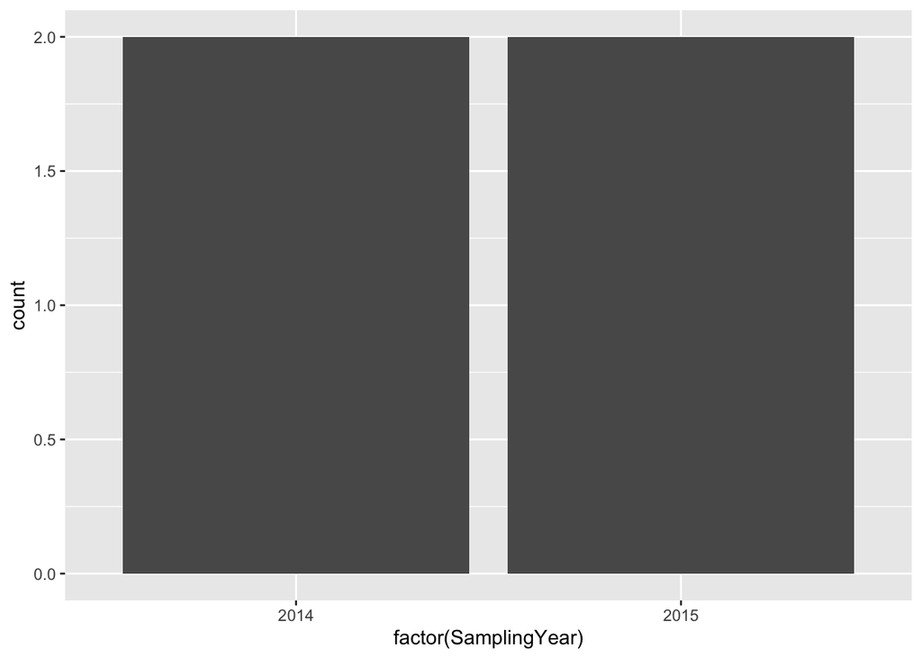

```r
df |> filter(Pittag==989001000415721) |>    # filter by pit tag
  ggplot() + geom_bar(aes(factor(SamplingYear))) # then plot only those rows
```

**Fox Time Series**

Find foxes that are observed across multiple months/years and create time series plots for them. Report how your findings align or differ from the population-analysis we did in the Introduction.